# Real Estate Pricing Data

Kady Barnes

05/01/2023

# Real Estate Data

My husband is in the military, so we tend to move often. We are getting to the point where we will want to purchase a house, so I want to analyze housing data to see what type of relationships there are in housing prices and other factors like time on the market, time of year, and total listings. While we may not have a lot of choice in where we go, there might be a better time to buy!

```r
library(tidyverse)
library(lubridate)
library(semTools)
library(ggplot2)
library(gridExtra)

Real_Estate_State <- read.csv(file = "Data/RDC_Inventory_Core_Metrics_State_History.csv",
    stringsAsFactors = TRUE)
```

## General Cleanup

- Review Data Types
- Review NAs
- Review Variables

### Determine if NAs should be removed

```r
sum(is.na(Real_Estate_State))
```

```
## [1] 15463
```

```r
total.na <- Real_Estate_State %>%
    group_by(Real_Estate_State$state) %>%
    summarize(sum(is.na(Real_Estate_State$median_listing_price_mm)))
total.na
```

```
## # A tibble: 52 × 2
##    `Real_Estate_State$state` sum(is.na(Real_Estate_State$median_listing_price_…¹
##    <fct>                                                                   <int>
##  1 alabama                                                                   613
##  2 alaska                                                                    613
##  3 arizona                                                                   613
##  4 arkansas                                                                  613
##  5 california                                                                613
##  6 colorado                                                                  613
##  7 connecticut                                                               613
##  8 delaware                                                                  613
##  9 district of columbia                                                      613
## 10 florida                                                                   613
## # … with 42 more rows, and abbreviated variable name
## #   ¹`sum(is.na(Real_Estate_State$median_listing_price_mm))`
```

```r
Real_Estate_Cleaned <- na.omit(Real_Estate_State)
sum(is.na(Real_Estate_Cleaned))
```

```
## [1] 0
```

```r
State.Count <- table(Real_Estate_State$state)
State.Count
```

```
##
##              alabama               alaska              arizona
##                   74                   74                   74
##             arkansas           california             colorado
##                   74                   74                   74
##          connecticut             delaware district of columbia
##                   74                   74                   74
##              florida              georgia               hawaii
##                   74                   74                   74
##                idaho             illinois              indiana
##                   74                   74                   74
##                 iowa               kansas             kentucky
##                   74                   74                   74
##            louisiana                maine     marshall islands
##                   74                   74                    1
##             maryland        massachusetts             michigan
##                   74                   74                   74
##            minnesota          mississippi             missouri
##                   74                   74                   74
##              montana             nebraska               nevada
##                   74                   74                   74
##        new hampshire           new jersey           new mexico
##                   74                   74                   74
##             new york       north carolina         north dakota
##                   74                   74                   74
##                 ohio             oklahoma               oregon
##                   74                   74                   74
##         pennsylvania         rhode island       south carolina
##                   74                   74                   74
##         south dakota            tennessee                texas
##                   74                   74                   74
##                 utah              vermont             virginia
##                   74                   74                   74
##           washington        west virginia            wisconsin
##                   74                   74                   74
##              wyoming
##                   74
```

```r
State.Count.Cleaned <- table(Real_Estate_Cleaned$state)
State.Count.Cleaned
```

```
##
##              alabama               alaska              arizona
##                   62                   30                   62
##             arkansas           california             colorado
##                   62                   62                   62
##          connecticut             delaware district of columbia
##                   62                   62                   62
##              florida              georgia               hawaii
##                   62                   62                   62
##                idaho             illinois              indiana
##                   62                   62                   62
##                 iowa               kansas             kentucky
##                   62                   62                   62
##            louisiana                maine     marshall islands
##                   62                   62                    0
##             maryland        massachusetts             michigan
##                   62                   62                   62
##            minnesota          mississippi             missouri
##                   62                   62                   62
##              montana             nebraska               nevada
##                   62                   62                   62
##        new hampshire           new jersey           new mexico
##                   62                   62                   62
##             new york       north carolina         north dakota
##                   62                   62                   62
##                 ohio             oklahoma               oregon
##                   62                   62                   62
##         pennsylvania         rhode island       south carolina
##                   62                   62                   62
##         south dakota            tennessee                texas
##                   62                   62                   62
##                 utah              vermont             virginia
##                   62                   62                   62
##           washington        west virginia            wisconsin
##                   62                   62                   62
##              wyoming
##                   62
```

### Review Data Types

```r
# lapply(Real_Estate_Cleaned, class)

dates <- ym(Real_Estate_Cleaned$month_date_yyyymm)
str(dates)
```

```
##  Date[1:3130], format: "2022-08-01" "2022-07-01" "2022-06-01" "2022-05-01" "2022-04-01" ...
```

```r
class(dates)
```

```
## [1] "Date"
```

#### Results:

- The only category that needs to be updated is the date formatting.

### Review Variables

- All variables appear normal with the exception of: Quality Flag. “Triggered (“1”) when data values are outside of their typical range. While rare, these figures should be reviewed before reporting.”

```r
# identify how many rows these affect:

length(which(Real_Estate_Cleaned$quality_flag == 0))
```

```
## [1] 3067
```

```r
length(which(Real_Estate_Cleaned$quality_flag == 1))
```

```
## [1] 63
```

```r
# There are 63 values that are listed as 1- meaning these are outside
# their typical range.  The data library does not state specifically
# what variable triggered the potential outlier.

grouped_quality_flag <- Real_Estate_Cleaned %>%
    group_by(state) %>%
    summarize(quality_flag = length(which(quality_flag == 1))) %>%
    arrange(desc(quality_flag))
grouped_quality_flag
```

```
## # A tibble: 51 × 2
##    state                quality_flag
##    <fct>                       <int>
##  1 district of columbia           11
##  2 utah                            6
##  3 arizona                         4
##  4 idaho                           4
##  5 michigan                        4
##  6 washington                      4
##  7 maine                           3
##  8 massachusetts                   3
##  9 new jersey                      3
## 10 pennsylvania                    3
## # … with 41 more rows
```

#### Results:

- The area with the highest potential outliers (‘1’) is Washington, D.C. with 11. Deleting these rows will reduce D.C. from 62 to 51, removing approximately 18% of its data. Additionally, 6 rows from Utah will be removed, accounting for approximately 10% of its data. At this time, I will not remove the quality flags that equal 1. I will monitor the results to see if there are any trends in these two states specifically that may give us any insights.

# Grouping Data to Begin Identifying Trends

- Are there any trends that can be seen with the data before I graph them?

## States and Dates

```r
# Grouping by date and state

Date.df.yr <- data.frame(date = c(format(dates, "%y")), average.price = c(Real_Estate_Cleaned$average_listing_price))

Date.df.month <- data.frame(date = c(format(dates, "%b")), average.price = c(Real_Estate_Cleaned$average_listing_price))

Date.df.yr %>%
    group_by(month = lubridate::floor_date(dates, "%y")) %>%
    summarize(average_price = mean(x = average.price)[1])
```

```
## # A tibble: 6 × 2
##   month      average_price
##   <date>             <dbl>
## 1 2017-01-01       451630.
## 2 2018-01-01       466341.
## 3 2019-01-01       483197.
## 4 2020-01-01       537360.
## 5 2021-01-01       610887.
## 6 2022-01-01       660138.
```

```r
Date.df.month %>%
    group_by(month = lubridate::floor_date(dates, "%b")) %>%
    summarize(average_price = mean(x = average.price)[1])
```

```
## # A tibble: 31 × 2
##    month      average_price
##    <date>             <dbl>
##  1 2017-07-01       453538.
##  2 2017-09-01       450860.
##  3 2017-11-01       450511.
##  4 2018-01-01       461389.
##  5 2018-03-01       473226.
##  6 2018-05-01       476685.
##  7 2018-07-01       468266.
##  8 2018-09-01       460742.
##  9 2018-11-01       457827.
## 10 2019-01-01       465271.
## # … with 21 more rows
```

#### Results:

- Sales have continued to increase steadily over the past several years; I thought there would be a dip in 2020, but there wasn’t. There also does not seem to be large differences in average price and the month.

#### Divide the states into 4 regions (determined by the Census Bureau) and the months into four seasons for a better picture when graphed and regressions performed.

```r
# Divided the states into 4 regions (determined by the Census Bureau)
# and divided the months into 4 seasons to allow a better visual
# picture.

Real_Estate_Cleaned_Recode <- Real_Estate_Cleaned %>%
    mutate(state = recode(.x = state, connecticut = "Northeast", maine = "Northeast",
        massachusetts = "Northeast", `new hampshire` = "Northeast", `rhode island` = "Northeast",
        vermont = "Northeast", `new jersey` = "Northeast", `new york` = "Northeast",
        pennsylvania = "Northeast")) %>%
    mutate(state = recode(.x = state, illinois = "Midwest", indiana = "Midwest",
        michigan = "Midwest", ohio = "Midwest", wisconsin = "Midwest",
        iowa = "Midwest", kansas = "Midwest", minnesota = "Midwest", missouri = "Midwest",
        nebraska = "Midwest", `north dakota` = "Midwest", `south dakota` = "Midwest")) %>%
    mutate(state = recode(.x = state, delaware = "South", florida = "South",
        georgia = "South", maryland = "South", `north carolina` = "South",
        `south carolina` = "South", virginia = "South", `district of columbia` = "South",
        `west virginia` = "South", alabama = "South", kentucky = "South",
        mississippi = "South", tennessee = "South", arkansas = "South",
        louisiana = "South", oklahoma = "South", texas = "South")) %>%
    mutate(state = recode(.x = state, arizona = "West", colorado = "West",
        idaho = "West", montana = "West", nevada = "West", `new mexico` = "West",
        utah = "West", wyoming = "West", alaska = "West", california = "West",
        hawaii = "West", oregon = "West", washington = "West")) %>%
    mutate(state = recode(.x = state, `marshall islands` = "Other")) %>%
    mutate(dates = as.factor(dates)) %>%
    mutate(dates = recode_factor(.x = dates, `2022-12-01` = "Winter", `2021-12-01` = "Winter",
        `2020-12-01` = "Winter", `2019-12-01` = "Winter", `2018-12-01` = "Winter",
        `2017-12-01` = "Winter", `2016-12-01` = "Winter", `2022-01-01` = "Winter",
        `2021-01-01` = "Winter", `2020-01-01` = "Winter", `2019-01-01` = "Winter",
        `2018-01-01` = "Winter", `2017-01-01` = "Winter", `2016-01-01` = "Winter",
        `2022-02-01` = "Winter", `2021-02-01` = "Winter", `2020-02-01` = "Winter",
        `2019-02-01` = "Winter", `2018-02-01` = "Winter", `2017-02-01` = "Winter",
        `2016-02-01` = "Winter", `2022-03-01` = "Spring", `2021-03-01` = "Spring",
        `2020-03-01` = "Spring", `2019-03-01` = "Spring", `2018-03-01` = "Spring",
        `2017-03-01` = "Spring", `2016-03-01` = "Spring", `2022-04-01` = "Spring",
        `2021-04-01` = "Spring", `2020-04-01` = "Spring", `2019-04-01` = "Spring",
        `2018-04-01` = "Spring", `2017-04-01` = "Spring", `2016-04-01` = "Spring",
        `2022-05-01` = "Spring", `2021-05-01` = "Spring", `2020-05-01` = "Spring",
        `2019-05-01` = "Spring", `2018-05-01` = "Spring", `2017-05-01` = "Spring",
        `2016-05-01` = "Spring", `2022-06-01` = "Summer", `2021-06-01` = "Summer",
        `2020-06-01` = "Summer", `2019-06-01` = "Summer", `2018-06-01` = "Summer",
        `2017-06-01` = "Summer", `2016-06-01` = "Summer", `2022-07-01` = "Summer",
        `2021-07-01` = "Summer", `2020-07-01` = "Summer", `2019-07-01` = "Summer",
        `2018-07-01` = "Summer", `2017-07-01` = "Summer", `2016-07-01` = "Summer",
        `2022-08-01` = "Summer", `2021-08-01` = "Summer", `2020-08-01` = "Summer",
        `2019-08-01` = "Summer", `2018-08-01` = "Summer", `2017-08-01` = "Summer",
        `2016-08-01` = "Summer", `2022-09-01` = "Fall", `2021-09-01` = "Fall",
        `2020-09-01` = "Fall", `2019-09-01` = "Fall", `2018-09-01` = "Fall",
        `2017-09-01` = "Fall", `2016-09-01` = "Fall", `2022-10-01` = "Fall",
        `2021-10-01` = "Fall", `2020-10-01` = "Fall", `2019-10-01` = "Fall",
        `2018-10-01` = "Fall", `2017-10-01` = "Fall", `2016-10-01` = "Fall",
        `2022-11-01` = "Fall", `2021-11-01` = "Fall", `2020-11-01` = "Fall",
        `2019-11-01` = "Fall", `2018-11-01` = "Fall", `2017-11-01` = "Fall",
        `2016-11-01` = "Fall"))


summary(Real_Estate_Cleaned_Recode$dates)
```

```
## Winter Spring Summer   Fall
##    759    756    856    759
```

```r
summary(Real_Estate_Cleaned_Recode$state)
```

```
##     South      West Northeast   Midwest     Other
##      1054       774       558       744         0
```

#### Results:

- We see that the Summer has the highest entries and the remaining seasons have relatively the lowest entries. This does not really tell us much yet without comparing it do a different variable.
- This also does not tell us much without comparing it to another variable, but the South has highest value here.

## Average Listing Price

```r
sort(tapply(Real_Estate_Cleaned$average_listing_price, Real_Estate_Cleaned$state,
    mean), decreasing = TRUE)
```

```
##               hawaii           california             new york
##            1396856.6            1237778.0            1148788.0
##             colorado        massachusetts district of columbia
##            1013154.8             968600.4             960824.2
##                 utah          connecticut              montana
##             864572.6             864351.3             765997.4
##              florida           washington                idaho
##             741469.1             692108.1             683032.3
##         rhode island               nevada              wyoming
##             669755.4             664886.9             644220.5
##               oregon              arizona           new jersey
##             615238.2             611128.4             599652.2
##        new hampshire             virginia              vermont
##             502368.9             489351.2             473305.9
##             maryland       north carolina       south carolina
##             471650.2             452354.9             447518.2
##                texas             delaware              georgia
##             446521.9             445312.2             441811.4
##            tennessee                maine           new mexico
##             437615.5             423963.9             417601.2
##               alaska            minnesota             illinois
##             404030.3             398656.5             391236.9
##            wisconsin         pennsylvania             michigan
##             351383.8             347753.2             332483.3
##         south dakota            louisiana              alabama
##             330621.3             330160.2             329974.5
##             nebraska             missouri             oklahoma
##             310483.9             304021.5             302626.8
##             kentucky         north dakota               kansas
##             302526.6             288690.0             288236.5
##             arkansas              indiana          mississippi
##             284992.3             283228.5             282086.1
##                 ohio                 iowa        west virginia
##             276877.0             259470.8             247042.8
```

```r
sort(tapply(Real_Estate_Cleaned$average_listing_price, Real_Estate_Cleaned$state,
    median), decreasing = TRUE)
```

```
##               hawaii           california             new york
##            1339815.0            1128075.5            1103088.0
## district of columbia             colorado        massachusetts
##             956219.5             941423.0             865405.0
##          connecticut                 utah              florida
##             752397.5             746167.5             671833.0
##           washington              montana              wyoming
##             664034.0             653164.5             631421.5
##               nevada         rhode island                idaho
##             625131.0             616304.5             593955.5
##              arizona           new jersey               oregon
##             582987.5             575697.0             567380.0
##             maryland             virginia        new hampshire
##             462536.0             461840.0             459653.5
##             delaware       south carolina       north carolina
##             430677.0             426735.5             425855.5
##                texas              vermont               alaska
##             421884.5             419614.5             406192.5
##              georgia            tennessee           new mexico
##             404593.0             397662.0             389037.5
##            minnesota                maine             illinois
##             387530.5             387246.0             381605.5
##            wisconsin         pennsylvania             michigan
##             342729.0             325992.0             322438.5
##              alabama         south dakota            louisiana
##             312754.0             309751.0             306143.5
##             nebraska             kentucky             oklahoma
##             293863.0             288023.0             286874.0
##             missouri               kansas         north dakota
##             286823.0             285210.5             281354.5
##              indiana                 ohio             arkansas
##             276945.5             273427.5             265970.5
##          mississippi                 iowa        west virginia
##             264499.5             254540.5             233084.0
```

```r
# Grouped by region:

State.Prices <- Real_Estate_Cleaned_Recode %>%
    group_by(state) %>%
    summarize(average_price = mean(x = average_listing_price)[1])
State.Prices
```

```
## # A tibble: 4 × 2
##   state     average_price
##   <fct>             <dbl>
## 1 South           436108.
## 2 West            785179.
## 3 Northeast       666504.
## 4 Midwest         317949.
```

```r
# Breaking down by season instead of specific months:

Season.Prices <- Real_Estate_Cleaned_Recode %>%
    group_by(dates) %>%
    summarize(average_price = mean(x = average_listing_price)[1])
Season.Prices
```

```
## # A tibble: 4 × 2
##   dates  average_price
##   <fct>          <dbl>
## 1 Winter       530091.
## 2 Spring       553256.
## 3 Summer       543722.
## 4 Fall         513602.
```

#### Results:

- Spring has the highest average price, with the lowest being Fall. This is interesting as I would have expected that Winter would be the lowest due to the cold. Although warmer climate regions like the West and South could be a contributing factor (selling a house in the fall or winter in these regions when it is not so hot). Additionally, the West has the highest average price, while the Midwest has the least.

## Median Days on Market

```r
# Grouped by state:

sort(tapply(Real_Estate_Cleaned$median_days_on_market, Real_Estate_Cleaned$state,
    mean), decreasing = TRUE)
```

```
##              vermont                maine              montana
##            110.90323             91.62903             88.59677
##        west virginia          mississippi              wyoming
##             87.20968             82.09677             80.87097
##             delaware            louisiana               hawaii
##             79.85484             75.32258             74.95161
##           new mexico             new york             arkansas
##             74.46774             74.27419             73.20968
##         north dakota              alabama       north carolina
##             73.09677             71.01613             69.69355
##              florida         pennsylvania       south carolina
##             68.58065             68.48387             68.29032
##            wisconsin               alaska             missouri
##             67.30645             64.83333             64.70968
##                 iowa          connecticut               kansas
##             64.53226             63.85484             63.72581
##             kentucky             oklahoma        new hampshire
##             63.64516             60.50000             60.43548
##             michigan             virginia                texas
##             57.77419             57.43548             56.22581
##             colorado           new jersey              indiana
##             55.30645             54.91935             54.83871
##         south dakota             illinois              georgia
##             54.70968             54.64516             54.50000
##            minnesota               oregon                 ohio
##             54.43548             54.27419             54.03226
##            tennessee             maryland                idaho
##             52.74194             52.66129             52.41935
##        massachusetts             nebraska         rhode island
##             51.59677             51.41935             50.98387
##              arizona                 utah               nevada
##             49.51613             49.32258             44.54839
##           washington           california district of columbia
##             43.38710             42.35484             39.20968
```

```r
sort(tapply(Real_Estate_Cleaned$median_days_on_market, Real_Estate_Cleaned$state,
    median), decreasing = TRUE)
```

```
##              vermont        west virginia          mississippi
##                108.0                 90.0                 88.0
##                maine              montana             delaware
##                 86.5                 86.5                 84.0
##               hawaii             arkansas            louisiana
##                 80.0                 78.0                 78.0
##              wyoming              florida           new mexico
##                 78.0                 75.0                 75.0
##             new york              alabama       south carolina
##                 74.0                 73.0                 72.5
##       north carolina         north dakota         pennsylvania
##                 71.0                 71.0                 69.0
##             kentucky            wisconsin               alaska
##                 66.0                 65.5                 65.0
##                 iowa             missouri               kansas
##                 65.0                 65.0                 64.0
##          connecticut             oklahoma        new hampshire
##                 61.0                 61.0                 58.5
##                texas              georgia             virginia
##                 57.0                 56.0                 56.0
##             michigan           new jersey              indiana
##                 55.5                 55.5                 55.0
##                 ohio            tennessee        massachusetts
##                 55.0                 54.5                 54.0
##              arizona             illinois             maryland
##                 53.5                 53.5                 52.5
##         south dakota             colorado               oregon
##                 52.5                 52.0                 51.5
##         rhode island             nebraska            minnesota
##                 51.5                 51.0                 50.5
##                 utah                idaho               nevada
##                 50.5                 49.0                 44.0
##           california           washington district of columbia
##                 42.0                 39.0                 37.0
```

```r
# Grouped by region:

State.Days <- Real_Estate_Cleaned_Recode %>%
    group_by(state) %>%
    summarize(median_days = mean(x = median_days_on_market)[1])
State.Days
```

```
## # A tibble: 4 × 2
##   state     median_days
##   <fct>           <dbl>
## 1 South            65.4
## 2 West             59.4
## 3 Northeast        69.7
## 4 Midwest          59.6
```

```r
# Grouped by season:

Season.Days <- Real_Estate_Cleaned_Recode %>%
    group_by(dates) %>%
    summarize(median_days = mean(x = median_days_on_market)[1])
Season.Days
```

```
## # A tibble: 4 × 2
##   dates  median_days
##   <fct>        <dbl>
## 1 Winter        80.0
## 2 Spring        56.5
## 3 Summer        53.7
## 4 Fall          64.3
```

## New Listing Count

```r
# Grouped by state:

sort(tapply(Real_Estate_Cleaned$new_listing_count, Real_Estate_Cleaned$state,
    mean), decreasing = TRUE)
```

```
##              florida                texas           california
##           43958.0645           38706.0645           38580.4516
##              georgia             illinois             new york
##           25170.1290           20013.9355           17064.8387
##       north carolina                 ohio           new jersey
##           14916.9677           14511.2903           14211.7419
##         pennsylvania             michigan             virginia
##           13924.0000           13379.3548           12687.3548
##              arizona             colorado            tennessee
##           11797.5484           10888.5161           10744.8387
##           washington       south carolina             missouri
##            9804.5161            8929.1613            8648.3226
##            minnesota             maryland              indiana
##            8292.7742            8023.2903            7802.3871
##        massachusetts            wisconsin               oregon
##            7718.9677            7105.1613            6417.7419
##              alabama                 utah             kentucky
##            6332.9677            5248.3871            5246.4516
##             oklahoma          connecticut            louisiana
##            4967.0968            4904.0000            4847.8710
##               nevada                 iowa             arkansas
##            4840.3871            4369.2903            3914.3226
##               kansas                idaho          mississippi
##            3556.9032            3245.2258            2612.3871
##           new mexico             nebraska        new hampshire
##            2516.5161            2411.8710            1931.7419
##                maine        west virginia               hawaii
##            1863.9355            1700.0645            1688.5806
##              montana         rhode island             delaware
##            1680.2581            1451.6774            1344.5161
##         south dakota district of columbia         north dakota
##            1075.0968             998.9677             891.0968
##              wyoming              vermont               alaska
##             870.1290             799.6774             648.5333
```

```r
sort(tapply(Real_Estate_Cleaned$new_listing_count, Real_Estate_Cleaned$state,
    median), decreasing = TRUE)
```

```
##              florida           california                texas
##                43824                39548                38174
##              georgia             illinois             new york
##                25306                20474                17582
##                 ohio       north carolina           new jersey
##                15380                15334                14988
##         pennsylvania             michigan             virginia
##                14514                13954                12910
##              arizona             colorado            tennessee
##                11832                11046                10882
##           washington       south carolina             missouri
##                10432                 9094                 9010
##            minnesota              indiana             maryland
##                 8864                 8174                 8170
##        massachusetts            wisconsin               oregon
##                 8068                 7482                 6552
##              alabama                 utah             kentucky
##                 6462                 5476                 5370
##          connecticut             oklahoma               nevada
##                 5120                 5008                 4916
##            louisiana                 iowa             arkansas
##                 4908                 4492                 3928
##               kansas                idaho          mississippi
##                 3708                 3216                 2646
##           new mexico             nebraska        new hampshire
##                 2552                 2536                 1946
##                maine        west virginia               hawaii
##                 1848                 1750                 1694
##              montana         rhode island             delaware
##                 1646                 1492                 1364
##         south dakota district of columbia         north dakota
##                 1144                 1008                  900
##              wyoming              vermont               alaska
##                  872                  778                  610
```

```r
# Grouped by region:
State.Listing <- Real_Estate_Cleaned_Recode %>%
    group_by(state) %>%
    summarize(new_listing = mean(x = new_listing_count)[1])
State.Listing
```

```
## # A tibble: 4 × 2
##   state     new_listing
##   <fct>           <dbl>
## 1 South          11477.
## 2 West            7841.
## 3 Northeast       7097.
## 4 Midwest         7671.
```

```r
# Grouped by season:

Season.Listing <- Real_Estate_Cleaned_Recode %>%
    group_by(dates) %>%
    summarize(new_listing = mean(x = new_listing_count)[1])
Season.Listing
```

```
## # A tibble: 4 × 2
##   dates  new_listing
##   <fct>        <dbl>
## 1 Winter       6933.
## 2 Spring       9787.
## 3 Summer      10164.
## 4 Fall         8526.
```

# Graphing Relationships for Visual Representation

## Date Versus Average Listing Price:

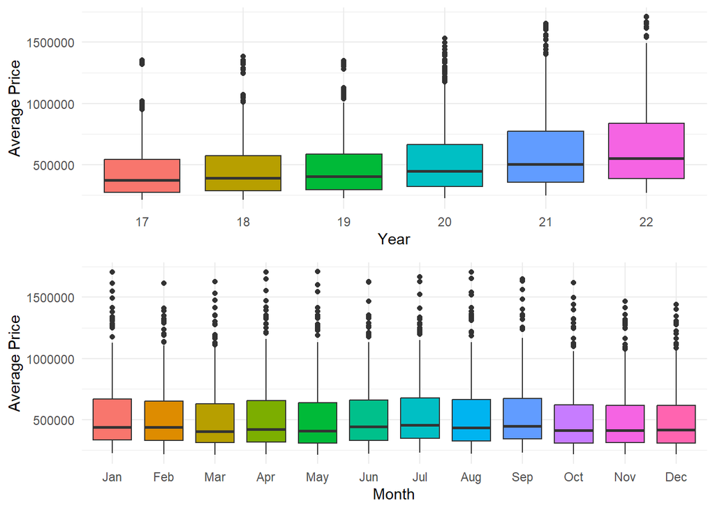

```r
Plot1 <- Date.df.yr %>%
    ggplot(aes(y = average.price, x = date, fill = date)) + geom_boxplot() +
    theme_minimal() + labs(x = "Year", y = "Average Price") + theme(legend.position = "none")


Plot2 <- Date.df.month %>%
    ggplot(aes(y = average.price, x = date, fill = date)) + geom_boxplot() +
    theme_minimal() + labs(x = "Month", y = "Average Price") + theme(legend.position = "none") +
    scale_x_discrete(labels = month.abb)

gridExtra::grid.arrange(Plot1, Plot2)
```

## Season Versus Average Listing Price:

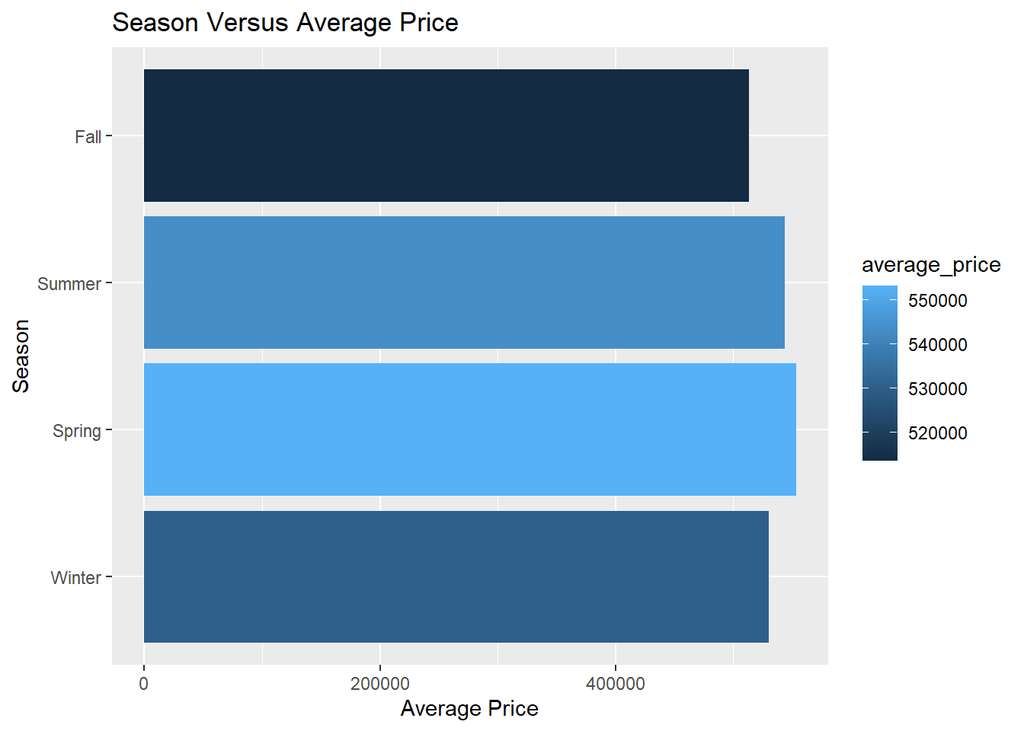

```r
options(scipen = 6)

ggplot(Season.Prices, aes(dates, average_price, fill = average_price)) +
    geom_bar(stat = "identity", position = "dodge") + coord_flip() + labs(x = "Season",
    y = "Average Price") + ggtitle("Season Versus Average Price")
```

#### Results: - This shows us a general increase in the average price over the years, but (at least visually), not a large difference in average price and month and season.

## Median List Price Versus Regions:

```r
Region.Prices <- Real_Estate_Cleaned_Recode %>%
    group_by(state) %>%
    summarize(median_price = mean(x = median_listing_price)[1])
Region.Prices
```

```
## # A tibble: 4 × 2
##   state     median_price
##   <fct>            <dbl>
## 1 South          298856.
## 2 West           446489.
## 3 Northeast      384417.
## 4 Midwest        236142.
```

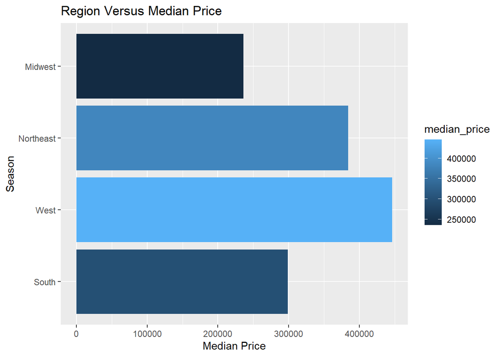

```r
ggplot(Region.Prices, aes(state, median_price, fill = median_price)) +
    geom_bar(stat = "identity", position = "dodge") + coord_flip() + labs(x = "Season",
    y = "Median Price") + ggtitle("Region Versus Median Price")
```

#### Results: - The West and Northeast have the highest average house prices with the Midwest coming in at the lowest average house prices.

## Median List Price Versus Seasons:

```r
Season.Median.Prices <- Real_Estate_Cleaned_Recode %>%
    group_by(dates) %>%
    summarize(median_price = mean(x = median_listing_price)[1])
Season.Median.Prices
```

```
## # A tibble: 4 × 2
##   dates  median_price
##   <fct>         <dbl>
## 1 Winter      323239.
## 2 Spring      344726.
## 3 Summer      348757.
## 4 Fall        324484.
```

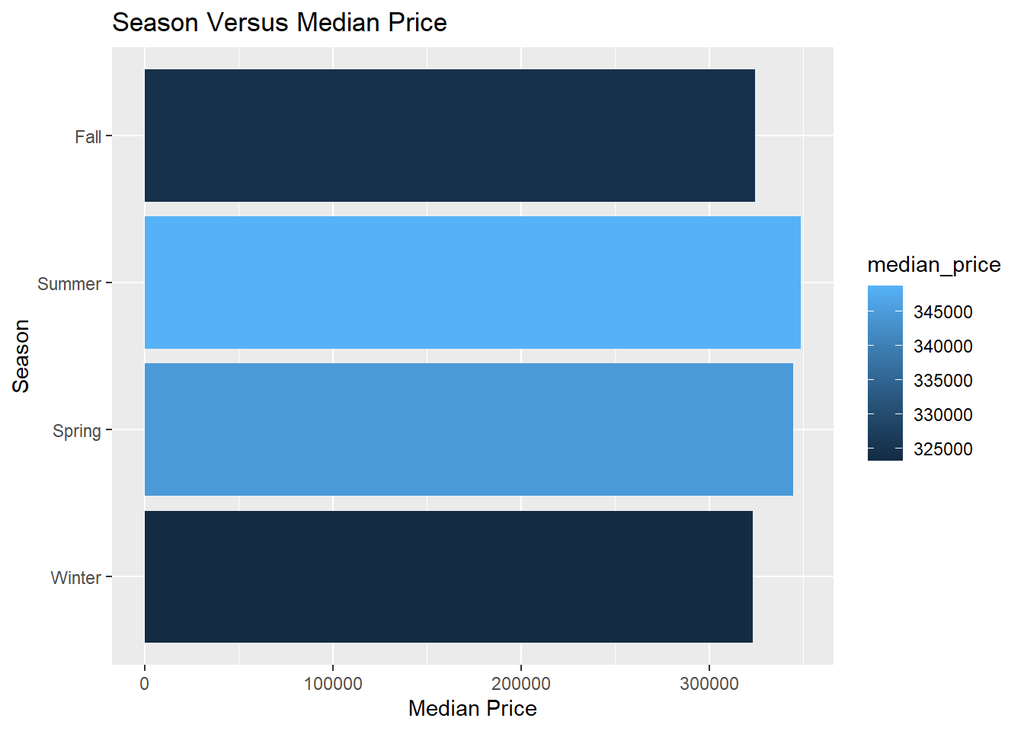

```r
ggplot(Season.Median.Prices, aes(dates, median_price, fill = median_price)) +
    geom_bar(stat = "identity", position = "dodge") + coord_flip() + labs(x = "Season",
    y = "Median Price") + ggtitle("Season Versus Median Price")
```

## Average Listing Price Versus New Listing Count:

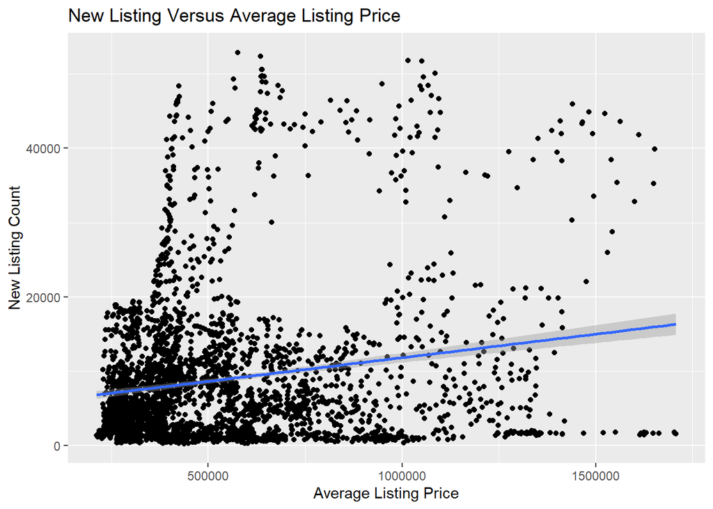

```r
AvgPrice.NewList <- Real_Estate_Cleaned %>%
    ggplot(aes(x = average_listing_price, y = new_listing_count)) + geom_point() +
    stat_smooth(method = "lm") + labs(x = "Average Listing Price", y = "New Listing Count") +
    ggtitle("New Listing Versus Average Listing Price")
AvgPrice.NewList
```

#### Results: - This graph shows a positive relationship between the two variables; as the average listing price increases, the new listing count increases as well; however, there are many outliers that could affect this relationship when looking at it statistically.